# MetaboTyping RA Agent Workbench

## Metabolomics Workbench census and RA Agent capabilities

**Condensed evidence report | MW corpus snapshot: 24 August 2026, 04:29 UTC**

MW counts in this report come from one frozen, provenance-tracked retrieval of the public bulk indexes. The report also shows how the MetaboTyping RA Agent Workbench can use those records. Study summaries, analyses, organism incidences, reported feature counts, and RefMet nomenclature entries remain separate because they have different denominators.

| Measure | Result | Interpretation |
| --- | --- | --- |
| MW study summaries | 4,499 | Unique `ST` records after one additional row sharing a study ID was removed |
| MW analyses | 7,367 | Unique analysis IDs after three additional rows sharing analysis IDs were removed |
| Organism coverage | 4,483 studies; 4,770 incidences; 481 labels | 4,395 single-species and 88 multi-species studies |
| Assay evidence | 2,385 untargeted; 14 explicit targeted; 4,968 unclassified | Analysis-level categories; targeted is a strict lower bound |
| Reported feature volume | 1,231,376 instances across 5,420 numeric records | Median 99 per reported analysis; not unique metabolites |
| RefMet reference snapshot | 205,948 entries | 23 superclasses, 333 main classes, 960 subclasses |
| Workbench inventory | 22 canonical roles; 24 logical skills | Two deprecated role aliases are not extra capabilities |
| Source-routing inventory | 28 sources; 27 lanes | Registration does not imply that every source has a live adapter |

## 1. Metabolomics Workbench corpus

### Study and species coverage

The official MW bulk endpoints returned 4,500 summary rows and 7,370 analysis rows. We kept the first record for each identifier. One additional summary row shared study ID `ST002097`, and three additional rows shared analysis IDs. After this step, the snapshot contained **4,499 studies and 7,367 analyses**. The rule makes identifiers unique; it does not show that rows sharing an identifier had identical content.

The species endpoint returned 4,773 rows representing 4,770 unique study-Latin-name pairs across 4,483 study IDs. Among those studies, 4,395 listed one species and 88 listed more than one. Eighteen studies in the summary index had no species-index row, and two species-index IDs had no matching summary row. Species percentages use the 4,483 annotated studies as the denominator. They can sum above 100% because a study may include more than one species.

| Rank | MW source label | Studies | Share of annotated studies |
| --- | --- | --- | --- |
| 1 | Homo sapiens | 1,852 | 41.31% |
| 2 | Mus musculus | 1,463 | 32.63% |
| 3 | Rattus norvegicus | 257 | 5.73% |
| 4 | Escherichia coli | 54 | 1.20% |
| 5 | Plasmodium falciparum | 53 | 1.18% |
| 6 | Drosophila melanogaster | 32 | 0.71% |
| 7 | Caenorhabditis elegans | 27 | 0.60% |
| 8 | Arabidopsis thaliana | 25 | 0.56% |
| 9 | Danio rerio | 24 | 0.54% |
| 10 | Saccharomyces cerevisiae | 24 | 0.54% |

### Targeted, untargeted, and unresolved assay scope

MW provides a dedicated `untarg_studies` index but no matching targeted-only bulk index. The untargeted index identifies **2,385 analyses in 1,250 studies**. A conservative search of the analysis text finds **14 explicitly targeted analyses in 14 studies**. The remaining **4,968 analyses** are **unclassified or other**; the available metadata do not support relabeling them as targeted. At the study level, 3,235 studies are neither explicitly targeted nor present in the untargeted index, or they have no analysis row. The current evidence therefore does not support a complete binary targeted/untargeted classification.

The `number_of_metabolites` endpoint returned 5,485 records: 5,420 numeric values and 65 blanks. Another 1,882 analyses had no count record. Numeric values ranged from 1 to 11,992, with a median of 99, and summed to **1,231,376 analysis-feature instances**. This is not a unique-metabolite count. The same chemical can recur across analyses, and an untargeted feature may not be an identified compound.

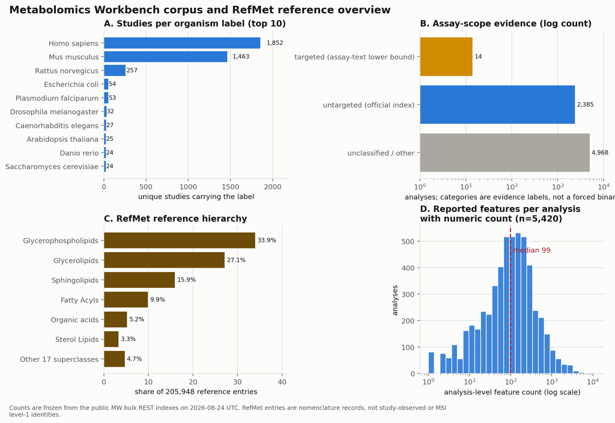

Figure 1. MW corpus overview. Species counts are study incidences, assay categories are analyses, and feature counts are analysis-level reported values. RefMet percentages describe a separate reference nomenclature snapshot.

## 2. RefMet chemical hierarchy

Here, superclass/class/subclass refers to the local **RefMet** hierarchy (`super_class`, `main_class`, `sub_class`), not a PubMed or PubChem classification. The snapshot contains **205,948 unique nomenclature entries**, including 205,919 with a nonblank formula, across 23 superclasses, 333 main classes, and 960 subclasses. The local source file does not record a release identifier. These rows are reference labels. They are not 205,948 chemicals shown to occur in MW, and a shared formula does not establish identity.

| Rank | Superclass (n) | Main class (n) | Subclass (n) |
| --- | --- | --- | --- |
| 1 | Glycerophospholipids (69,886) | Triradylglycerols (33,688) | TAG (33,431) |
| 2 | Glycerolipids (55,850) | Glycosphingolipids (16,592) | FAHFA (14,719) |
| 3 | Sphingolipids (32,811) | Fatty esters (15,818) | HexCer (10,579) |
| 4 | Fatty Acyls (20,340) | Glycerophosphoglycerols (15,387) | Tripeptides (8,017) |
| 5 | Organic acids (10,648) | Glycerophosphoethanolamines (12,424) | O-DG (5,770) |

The three largest superclasses account for 76.98% of the entries, so the reference file is heavily weighted toward lipids. That pattern describes RefMet itself. Applying it to MW observations would first require a study-analysis-feature crosswalk and supporting identity evidence.

## 3. Worked comparisons: MoTrPAC and Lac-Phe

### Acute human MW-MoTrPAC comparison

We compared MW study `ST004303` (266 effect rows; 261 case/space-normalized labels) with the cached public MoTrPAC human acute-endurance late-post-versus-pre plasma effect table (1,657 rows; 1,509 normalized labels across 11 targeted and untargeted panels). The screen found **99 exact case/space-normalized label overlaps** and **102 punctuation-insensitive candidate name-key overlaps**. Duplicate labels or panels made 46 of the 102 candidates ambiguous. The other **56 were unique in both tables at the duplicate-key screening gate**. Neither table carries source-stable RefMet identifiers, so none of these candidates is treated as structurally validated or ready for pooling. They form a review queue; no meta-analysis was run.

### Lac-Phe worked example

An exact RefMet-name query for `N-Lactoyl phenylalanine` returned 85 raw MW metabolite-statistics rows; the variants `Lac-Phe` and `N-lactoylphenylalanine` returned none. After repeated study-analysis pairs were removed, **60 label-associated study-analysis pairs from 57 studies** remained, including 24 analyses from 22 human studies. The resolver's database annotation for N-Lactoyl phenylalanine is RefMet `RM0131640` (formula `C12H15NO4`; PubChem `11075454`). This annotation does not prove the identity of the focal feature. The public source we inspected did not document linked authentic-standard retention time plus MS/MS evidence for that feature. It therefore stays in the human-review queue and is not assigned MSI level 1.

For the study-reported whole-blood feature labeled `Lactoyl Phenylalanine` in `ST003662`, 116 of 137 participant rows had complete positive-abundance pre/post values. **Ninety-two of the 116 increased.** The acute post-minus-pre analysis used participant-level `log2(post) - log2(pre)` differences and estimated a mean paired log2 fold change of **+1.1586** (geometric mean paired fold **2.23x**), with p = **2.73e-15** and BH FDR = **2.50e-14**. This was the fourth-largest log2 fold change among 165 usable all-athlete estimates. In the study-reported whole-blood units, arithmetic means rose from 0.539 to 0.755 micromol/L, a ratio of 1.40. That ratio and the paired log-scale estimate answer different questions and should not be interchanged. The inspected source did not encode protocol modality, intensity, duration, or the post-exercise sampling delay.

The RefMet snapshot contains 22 labels beginning with `N-Lactoyl`. MW metabolite statistics associate 17 of them with at least one study-analysis pair. Only the Lac-Phe label is associated with `ST003662`, and none of the 22 labels appears in the inspected cached public human acute-plasma or rat MoTrPAC tables. We record the missing labels as a **coverage gap**. Their biological effects remain unknown.

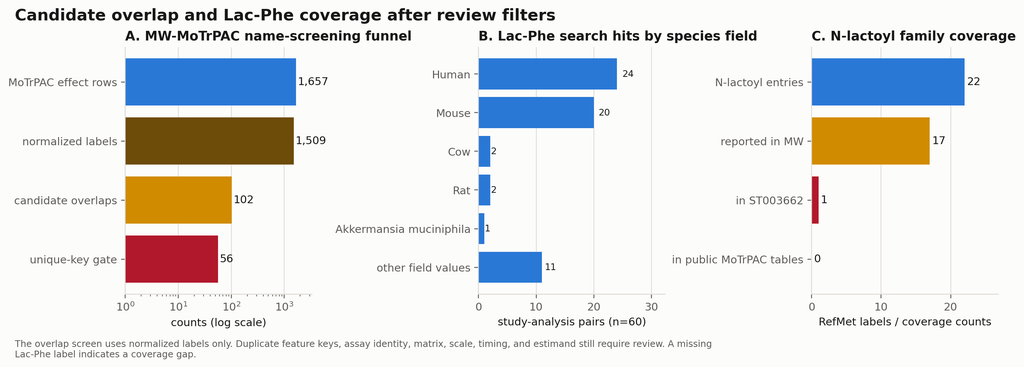

Figure 2. Review filters applied to the MW-MoTrPAC name screen and the Lac-Phe example. Fifty-six name-key candidates remain unambiguous, but their chemical identity is not verified. The Lac-Phe RefMet label is associated with several MW-reported species fields, and N-lactoyl coverage differs across RefMet, MW, the focal study, and cached MoTrPAC tables.

## 4. Current capabilities

Deterministic Python code runs the core workflows. Agent and skill contracts define what each role may do and when human review is required. The current inventory has 22 canonical roles and 24 logical project skills; mirrored Codex and Claude copies count once. The roles assign responsibility for source retrieval, metadata and identity review, statistical review, plotting, and pipeline planning.

| Workflow | Reviewable output | Scientific safeguard |
| --- | --- | --- |
| Discovery | Inclusion criteria, ranked studies, literature and repository evidence | Missing repository support is flagged for review |
| Metadata extraction | Study, dataset, variable, timing, assay, and provenance cards | Unknown stays unknown; it is not converted to absent |
| Identity and harmonization | Identity candidates, confidence-scored crosswalks, assay-aware plans | Similar names do not authorize a merge or pooling |
| Comparison and plotting | MoTrPAC-style effects, overlap screens, descriptive RefMet-class and supplied-pathway views | Descriptive overlap is not reported as replication or pathway inference |
| Review and reporting | Queues, advisory domain packets, manifests, scored readiness, reports | Domain packets stay advisory; mappings under review produce no transform |

The source registry contains 28 sources across 27 retrieval lanes. Some lanes have live core adapters; others use offline snapshots, optional life-science connectors, standards references, or planned/manual routes. Registration records where a request should go. It does not prove that live retrieval works. The current synthetic/local release gate ran **150 tests and all passed**. In the synthetic benchmark, candidate precision/recall and review capture were 1.00, unsafe auto-accept was 0/12, and quality-score agreement within 0.15 was 8/10. These results check reproducibility on constructed fixtures, not performance on an independent external dataset.

The current implementation does not reconcile chemical structures automatically across every source. It leaves unreported features as unknown and blocks pooling until matrices, assays, units, scales, time points, protocols, and estimands are compatible. Several registered sources still lack executable adapters. The supporting files are the frozen MW manifest, derived evidence bundle, skill audit, scientific-readiness audit, and full Lac-Phe dossier.

## Summary

The MetaboTyping RA Agent Workbench helps research teams find, curate, and compare metabolomics datasets without hiding the judgment calls. The current worktree has 22 canonical agent roles and 24 project skills mirrored across Codex and Claude; two older role names remain only as aliases. The workflow turns a research question into inclusion criteria, ranks candidate studies, keeps repository records and provenance intact, and produces study, dataset, and variable cards. It can also flag uncertain metabolite identities, propose confidence-scored crosswalks, draft assay-aware harmonization plans, assess dataset readiness, review literature, and render MoTrPAC-style figures and review packets. Shared names do not justify a merge. Uncertain mappings go to human review, and pooling requires both compatibility evidence and human approval.

The frozen MW snapshot contains 4,499 study summaries and 7,367 analyses. Species metadata cover 4,483 study IDs and 4,770 study-organism incidences across 481 source labels. MW identifies 2,385 analyses in 1,250 studies as untargeted. Only 14 analyses are explicitly labeled targeted in assay text; the other 4,968 remain unclassified and cannot be relabeled targeted from the available evidence. The local RefMet file is separate. It contains 205,948 nomenclature entries across 23 superclasses, 333 main classes, and 960 subclasses, not 205,948 metabolites observed in MW. The acute human screen found 102 punctuation-insensitive candidate name-key overlaps between MW `ST004303` and the cached public human acute-endurance late-post-versus-pre plasma effect table; 56 were unique on both sides at the duplicate-key screening gate. The exact RefMet-name search returned Lac-Phe label associations for 57 studies and 60 study-analysis pairs. In `ST003662`, the whole-blood feature labeled `Lactoyl Phenylalanine` increased by a mean paired log2 fold change of 1.16 across 116 complete pairs. The inspected cached public human acute-plasma and rat MoTrPAC tables did not contain that label. The missing label is treated as unmeasured coverage, not a null effect. Identity and pooling remain under review.

**Provenance note.** MW counts came from documented MW REST v1.2 bulk endpoints through the repository's allowlisted fetcher. The frozen files include raw payloads, normalized tables, SHA-256 hashes, endpoint URLs, timestamps, row counts, and de-duplication rules. RefMet, Lac-Phe, MoTrPAC, agent/skill, and test counts come from local snapshots. Their source files and derived tables are listed in `data/report_metrics.json` and the adjacent CSV bundle.